# AQUASCOPE

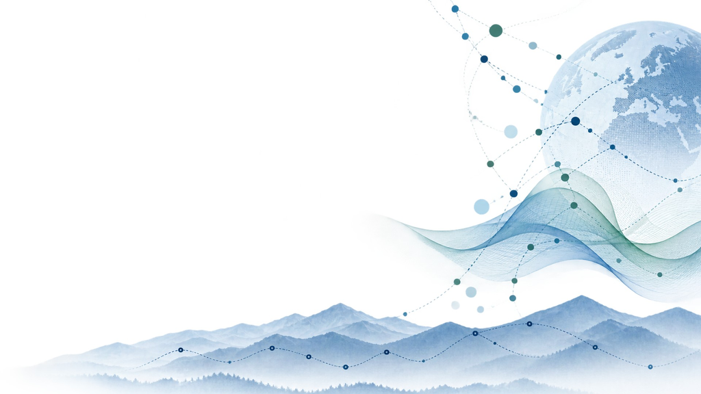

FOREMA StatisticsLab Colloquium  
Understanding Change Between Observations

AQUASCOPE

Integrating high resolution monitoring and trait-based modelling to understand and predict phytoplankton dynamics

Dr. Leonardo Capitani

Department of Aquatic Ecology, Eawag

21 October 2026 · WSL Birmensdorf

1 / 21

## Slides and links

[figure not shown]

[figure not shown]

Scan to download

[figure not shown]

2 / 21

## Take home message

[figure not shown]

[figure not shown]

PI Dr. Francesco Pomati  
(Plankton Ecology Group)

PI Marco Baity-Jesi  
(Machine Learning & Complex Systems)

We collaborate. Therefore we overcome research limitations.

3 / 21

## Meet Aquascope

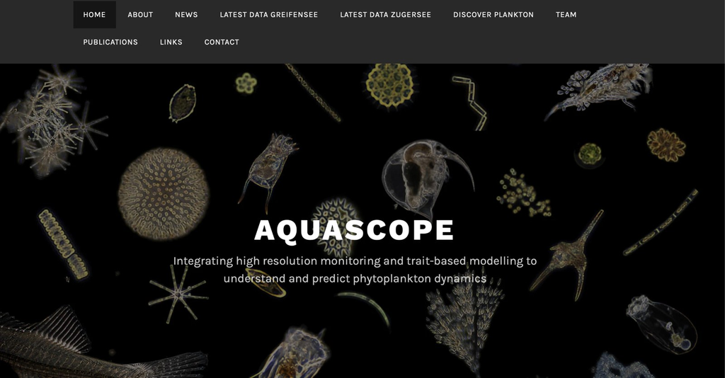

www.aquascope.ch

4 / 21

## Why plankton?

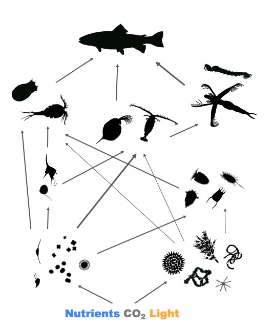

Sensitive sentinels

Fast turnover

Harmful blooms

Whole food web

Fast plankton turnover

5 / 21

## Monitoring mismatch

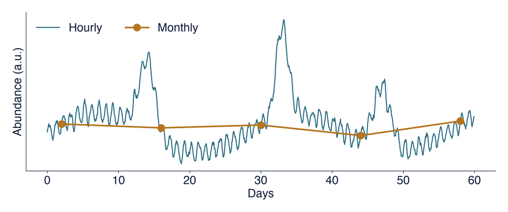

Monthly misses blooms

Schematic, simulated data

6 / 21

## Three-step pipeline

1

Sampling

Aquascope-Camera

➜

2

Classification

Deep learning

➜

3

Modelling

Empirical Dynamic Modelling

7 / 21

## Step 1 · Aquascope-Camera

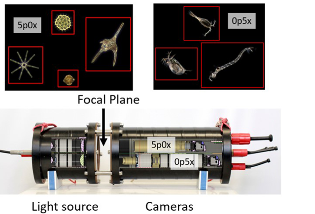

Dark-field microscope

Two magnifications

1 µm – 1 mm

Every few minutes

Assumption

Imaged volume representative

Undisturbed organisms

Stable detection

Seeing without sampling

Merz et al. 2021, Water Research 203, 117524, Fig. 1

8 / 21

## Step 1 · Lake Greifensee station

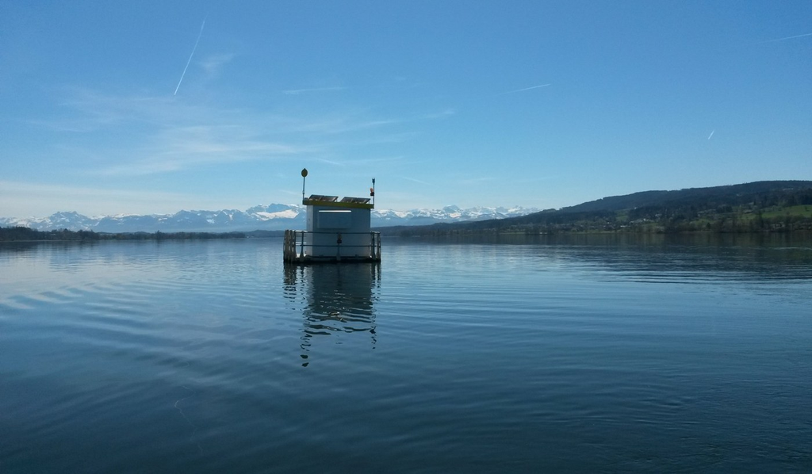

Since 2018

3 m depth

[figure not shown]

Whole plankton community

Pomati group, Eawag · www.aquascope.ch

9 / 21

## Step 2 · Image classification

Image

➜

Deep learning

➜

Taxon

➜

Abundance

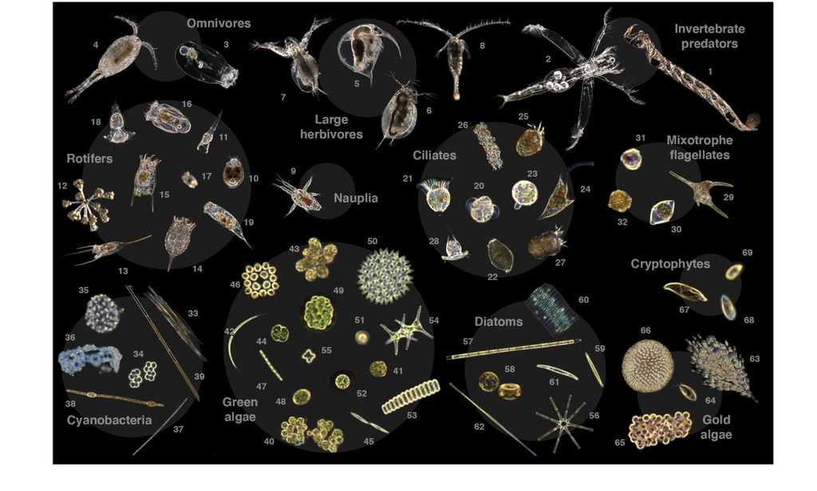

Assumption

Deployment resembles training

Expert labels correct

Images become counts

Kyathanahally et al. 2021, Front. Microbiol. 12, 746297; Chen et al. 2025, L&O Methods 23, 39–66

10 / 21

## Step 2 · Imaging and classification performance

Camera vs microscopy

0.96

R² body size

0.89

R² phytoplankton density

0.73

R² zooplankton density

Classifier

35

Classes

17,900+

Annotated images

98%

Accuracy

93%

F1 score

Validated against microscopy

Merz et al. 2021, Water Research 203, 117524 · Kyathanahally et al. 2021, Front. Microbiol. 12, 746297

11 / 21

## Real-time dashboard

[figure not shown]

aquascope.ch

[figure not shown]

datalakes-eawag.ch/datadetail/1387

Live plankton composition

Daily abundances from image classifiers · Datalakes, Eawag

12 / 21

## Step 3 · Workshop on Empirical Dynamic Modelling

Advanced time series analysis using EDM

25–27 August 2026 · Eawag

Guests: Steve Munch, Tanya Rogers

[figure not shown]

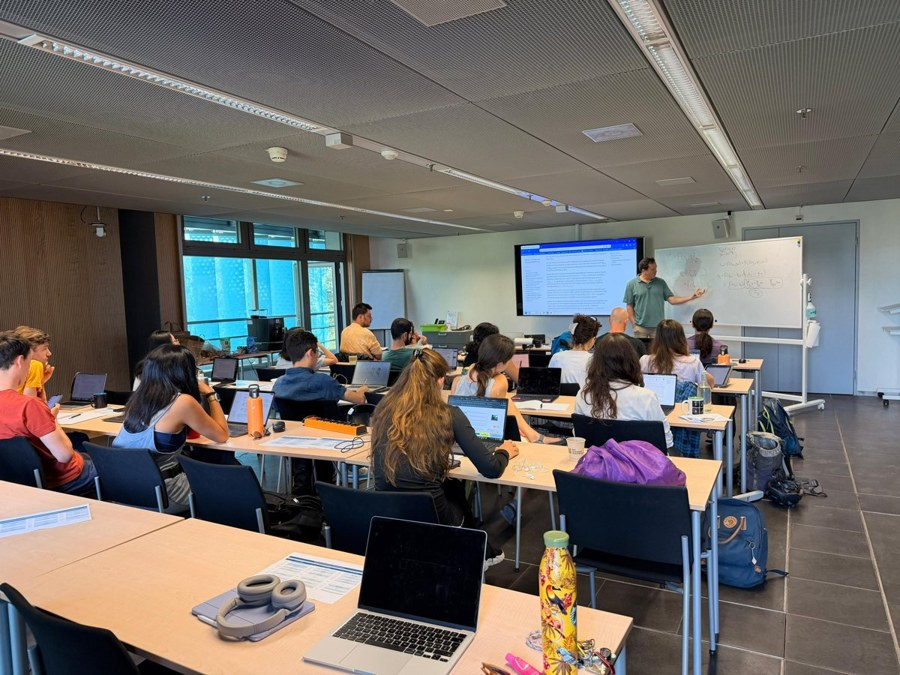

[figure not shown]

[figure not shown]

[figure not shown]

[Supported by: Biodiversity Center WSL–Eawag](https://biodiversitycenter.wsl.ch/en/?show=13)[Workshop material: leomarameo7.github.io](https://leomarameo7.github.io/science_communication.html)

The importance of knowledge exchange in situ

13 / 21

## Step 3 · Empirical Dynamic Modelling

[video not shown]

Video: [Introduction to Empirical Dynamic Modeling, Sugihara Lab (YouTube)](https://www.youtube.com/watch?v=fevurdpiRYg) · Takens 1981; Sugihara & May 1990

14 / 21

## Step 3 · EDM assumptions

- Equal sampling intervals
- Stationary time series
- Enough data points (≥ 35–40)
- Moderate measurement and process error
- Low-dimensional, deterministic dynamics
- No smoothing; seasonality can mask

Chang, Ushio & Hsieh 2017, Ecological Research 32, 785–796 (Data issues; errors; time series length)

15 / 21

## Step 3 · Handling missing data

1

Exclusion

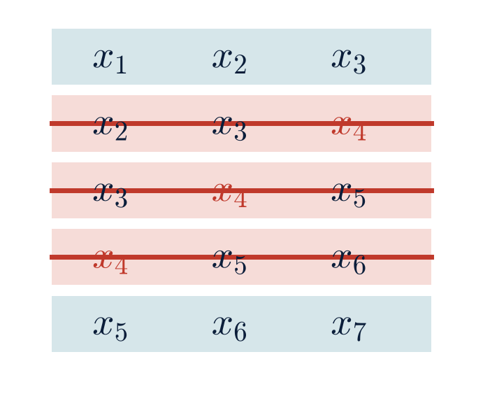

Drop incomplete vectors

Wastes data

2

Interpolation

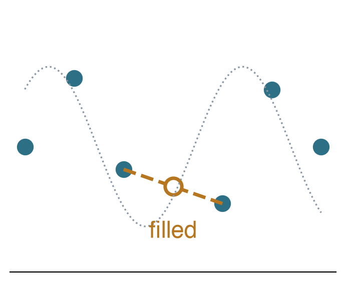

Fill, then standard EDM

Adds bias

3

Variable step-size

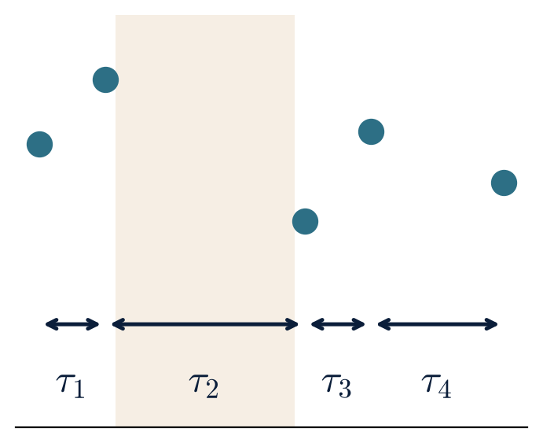

Add gaps as inputs

Doubles inputs

Three ways, three trade-offs

Johnson & Munch 2022 (complete-case: Little 1992; linear interpolation: Ye et al. 2015; bundle embedding: Stark et al. 1997; Stark 1999)

16 / 21

## Step 3 · Variable step-size EDM

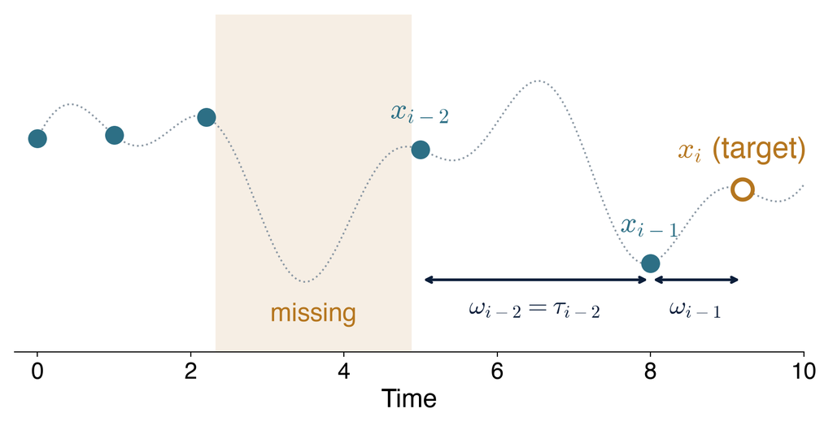

Add time gaps

➜

Dimension E → 2E

Bundle-embedding theorem

Extends Takens to forced systems: add forcing lags ω

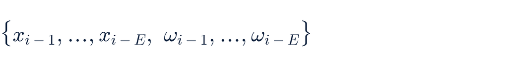

Environmental driversHarvesting

Stark: ω = τ (time between samples)

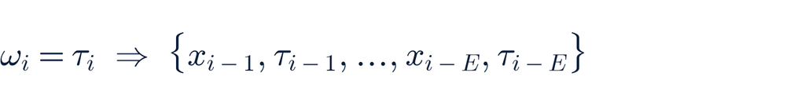

ω = τ: the next state depends on the current state and on how long we waited.

**Bonus:** extrapolate back to continuous-time dynamics

Gaps become inputs

Johnson & Munch 2022, Ecological Modelling 468, 109948 · Bundle-embedding theorem: Stark et al. 1997; Stark 1999 · τ as forcing: Stark 1999

17 / 21

## Step 3 · EDM: inputs and outputs examples

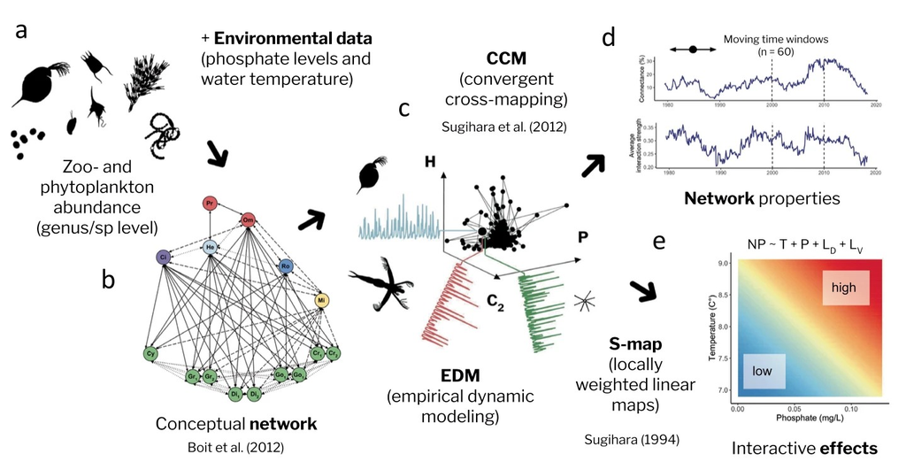

Temperature

Nutrients

Density dependence

Time-varying interactions

Pomati group schematic · Boit et al. 2012; Sugihara 1994; Sugihara et al. 2012

18 / 21

## Take home message

[figure not shown]

We collaborate. Therefore we overcome research limitations.

19 / 21

## Thank you

Dr. Leonardo Capitani

Department of Aquatic Ecology, Eawag

**Pomati group & colleagues:** **Francesco Pomati** · Ewa Merz · Marta Reyes · Pinelopi Ntetsika · Steffi Eyring · Stuart Dennis · Christian Ebi · Marco Baity-Jesi · Luis Gilarranz · Rudolf Rohr · Agostino Merico · Serguei Saavedra · George Sugihara · Steve Munch · Jules Jaffe · Paul Roberts · Jean-Olivier Irisson · Raphael Bossart · Gabi Koerich · Elisabeth Janssen · David Johnson · Jon Norberg

[figure not shown]

[figure not shown]

[figure not shown]

leomarameo7.github.io

20 / 21

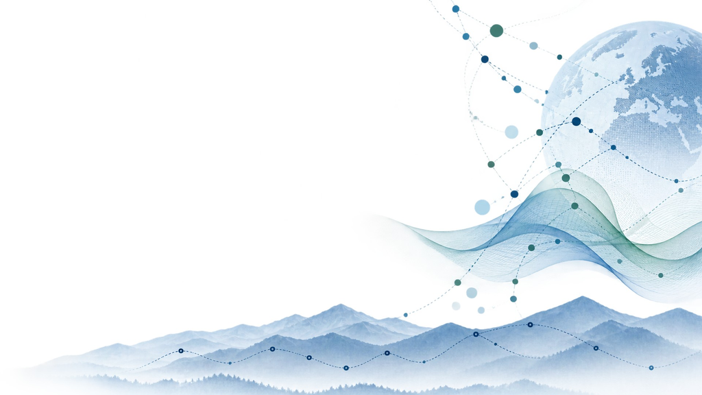

Supplementary materials

21 / 21